### Part II

#### Solution

Tuesday, May 19, 2015

**4.** Let $X_1, X_2, \dots, X_{500}$ represent $n=500$ independent and identically distributed observations from a beta distribution with pdf
$$f(x) = \frac{\Gamma(\theta + \beta)}{\Gamma(\theta) \Gamma(\beta)}x^{\theta - 1}(1 - x)^{\beta - 1}; \ \ \ 0 <x < 1; \ \theta, \beta >0$$
We are interested in testing $H_0: \theta=1$ versus $H_1: \theta > 1$. The data can be found in the file `prob4.dat`.

Beta distribution under $H_0 (\theta=1)$:

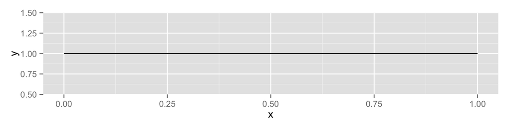

Note that when $\beta=\theta=1$, the pdf becomes $f(x)=1$. That is, $X \sim Unif(0,1)$.

1. Assuming $\beta=1$, derive the likelihood ratio test statistic. Furthermore, argue that an equivalent test can be based on the statistic
   $$T(X) = - \sum_{i=1}^n \ln X_i$$
   **Solution** We will use the generalized likelihood ratio test where we compare the null hypothesis against the mle of the entire sample space:
   $$\Lambda = \frac{\max_{\theta \in \omega_0} L(\theta)}{\max_{\theta \in \Omega} L(\theta)}$$
   $H_0$ is strictly defined for us ($\theta_0=1$), so no derivation is necessary for the mle. For $\theta_1$:
   $$\begin{align*}
   L(\theta, \beta=1) &= \prod_{i=1}^n \frac{\Gamma(\theta + 1)}{\Gamma(\theta) \Gamma(1)}x_i^{\theta - 1}(1 - x_i)^{1 - 1} \\
   &= \prod_{i=1}^n \frac{([\theta + 1] -1)!}{(\theta - 1)! \cdot (1-1)!}x_i^{\theta - 1}\cdot 1 \\
   &= \prod_{i=1}^n \theta x^{\theta - 1} \\
   \log\big[L(\theta, \beta=1)\big] &= \log \bigg[\prod_{i=1}^n \theta x_i^{\theta - 1} \bigg] \\
   \ell (\theta, \beta=1) &= \sum_{i=1}^n \log \big(\theta x_i^{\theta - 1} \big) \\
   &= \sum_{i=1}^n \big[\log \theta + \log x_i^{\theta - 1} \big] \\
   &= n \log \theta + (\theta - 1) \sum_{i=1}^n \log x_i \\
   \frac{\partial \ell}{\partial \theta} &= \frac{n}{\hat{\theta}} + \sum_{i=1}^n \log \theta \\
   \end{align*}$$
   Maximize $\hat{\theta}$ by setting the derivative to zero, and solve for $\hat{\theta}$:
   $$\hat{\theta} = - \frac{n}{\sum_{i=1}^n \log X_i}$$
   The likelihood ratio test:
   $$\begin{align*}
   \Lambda &= \frac{\prod_{i=1}^n \frac{\Gamma(\theta_0 + 1)}{\Gamma(\theta_0) \Gamma(1)}x_i^{\theta_0 - 1}(1 - x_i)^{1 - 1}}{\prod_{i=1}^n \frac{\Gamma(\hat{\theta} + 1)}{\Gamma(\hat{\theta}) \Gamma(1)}x_i^{\hat{\theta} - 1}(1 - x_i)^{1 - 1}} \\
   & \\
   &= \frac{\prod_{i=1}^n \frac{\Gamma(1 + 1)}{\Gamma(1) \Gamma(1)}x_i^{1 - 1} \cdot 1}{ \left(\frac{\Gamma(\hat{\theta} + 1)}{\Gamma(\hat{\theta}) \Gamma(1)} \right)^n \prod_{i=1}^n x_i^{\hat{\theta} - 1} \cdot 1} \\
   &= \frac{1}{\hat{\theta}^n \prod_{i=1}^n x_i^{\hat{\theta} - 1}} \\
   \end{align*}$$
   Take the logarithm of the ratio:
   $$\begin{align*}
   \log \Lambda &= \log \left( \frac{1}{\hat{\theta}^n \prod_{i=1}^n x_i^{\hat{\theta} - 1}} \right) \\
   &= \log 1 - (\log \hat{\theta}^n + \log \prod_{i=1}^n x_i^{\hat{\theta} - 1}) \\
   &= 0 - n \log \hat{\theta} - (\hat{\theta} - 1) \sum_{i=1}^n \log x_i \\
   &= - n \log \hat{\theta} - \hat{\theta} \sum_{i=1}^n \log x_i + \sum_{i=1}^n \log x_i \\
   &= - n \log \hat{\theta} - \left(- \frac{n}{\sum_{i=1}^n \log x_i}\right) \sum_{i=1}^n \log x_i + \sum_{i=1}^n \log x_i \\
   &= - n \log \hat{\theta} + n + \sum_{i=1}^n \log x_i \\
   \end{align*}$$
   Because $0 < x < 1$, $\log x < 0$. Then $\log \Lambda$ is a monotonically increasing function of $T(X) = -\sum_{i=1}^n \log X_i$. Therefore, rejecting for small values of $\Lambda$ (meaning, rejecting $H_0$) is equivalent to rejecting for small values of $\log \Lambda$ which is equivalent to rejecting for small values of $T(X)$.
2. Use a resampling method to estimate the rejection region for this test based on $T(X)$, from part (a), under the null hypothesis at $\alpha = 0.05$. Then make the appropriate conclusion to the hypothesis test using the data. Explain all steps. Include all code.  
   **Solution**  
   We will generate 500 random variables from $H_0: \theta_0=1$. These will be stored in the variable `x.simulated`. (It is given that $\beta=1$.)

```r
x.simulated <- rbeta(n=500,
                     shape1=1, # theta parameter
                     shape2=1) # beta parameter
```

Then we will use the bootstrap method which, for each of the 5000 trials, will take 500 samples (with replacement) from `x.simulated`. Then we will compute $T(X) = - \sum \ln X_i$ for each trial. Each calculation of $T(X)$ will be stored in the vector `t.x`. This will serve as our estimated bootstrap distribution.

```r
t.x <- c()           # vector of simulated likelihood ratios, sum of log(x)

# 5000 trials
for (i in 1:5000) {
  trial <- sample(x=x.simulated, size=500, replace=TRUE)
  t.x[i] <- - sum(log(trial))
}
```

Because we are rejecting $H_0$ when $T(X)$ is small, the rejection region is below the 5th percentile.

```r
quantile(x=t.x, probs=0.05) # border of rejection region
```

```
##       5%
## 435.3208
```

The rejection region is $T(X) <$ 435.3207567

Compare that to the data given to us:

```r
-sum(log(data.500)) # T(X) for the data provided.
```

```
## [1] 400.9059
```

400.9058761 $<$ 435.3207567, so we reject $H_0$. We conclude that $\theta > 1$.

3. Now use the fact that $T(X)$ above actually follows a $\text{gamma}(n, 1/\theta)$ distribution to calculate the power of the test if $\theta = 1.2$.  
   **Solution**  
   $T(X) \sim \text{gamma}(n, 1/\theta)$.  
   The power of a test is the probability of correctly rejecting $H_0$ given that it is false. To get a sense of the two distributions, we have

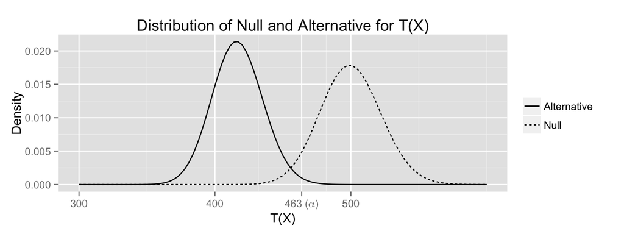

We are interested in determining the area under the curve for $H_1$ below the point $\alpha$ on the graph.

```r
threshold <- qgamma(p=.05,shape=500,scale=1/1) # rejection border, assuming H0
pgamma(q=threshold, shape=500, scale=1/1.2)
```

```
## [1] 0.9929466
```

4. Plot the power function of this test as a function of $\theta > 1$. What value of $\theta$ is necessary to achieve a power of at least $0.8$ (this needs to be solved numerically, not by looking at the plot)?
   **Solution**
   Power of test:
   $$P_{\theta_1}[T(X) < k]$$
   Plot:

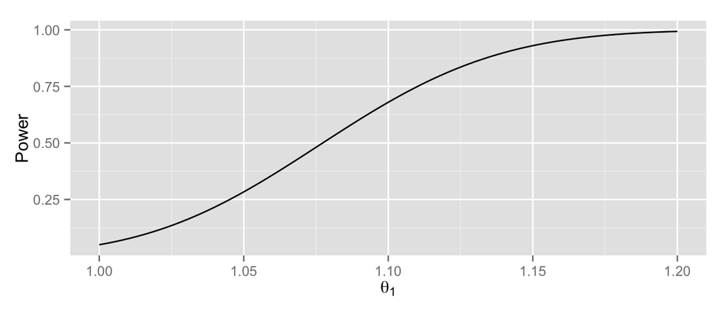

```r
# ggplot
ggplot(data.frame(x=c(1, 1.2)), aes(x)) +
  stat_function(fun=function(x) pgamma(qgamma(.05, 500, scale=1/1),500, scale=1/x)) +
  labs(x=expression(theta[1]), y="Power")
```

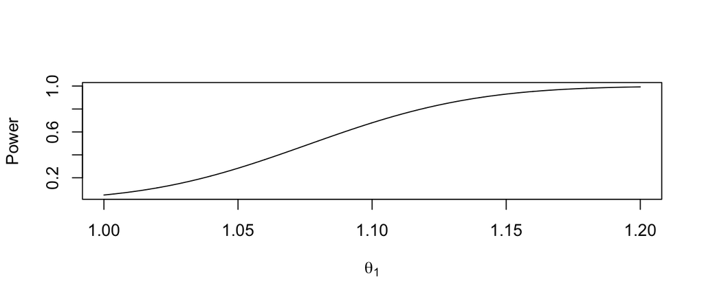

```r
# base R
theta.1 <- seq(from=1, to=1.2, length=1000)
plot(x=theta.1,
     y=pgamma(qgamma(.05,500,scale=1/1),500,scale=1/theta.1),
     type='l',
     ylab='Power',
     xlab=expression(theta[1]))
```

Determining the value of $\theta$ that will give us a power of $0.8$:

```r
pwr.8 <- function(theta1){
  threshold <- qgamma(p=.05,shape=500,scale=1/1)
  power <-  pgamma(q=threshold, shape=500, scale=1/theta1)
  abs(power - 0.8) # tells us distance from a power of 0.8
}
optimize(f=pwr.8, interval=c(1, 1.2))
```

```
## $minimum
## [1] 1.118386
##
## $objective
## [1] 0.0001390023
```

$\theta_1=1.118$ will give us a power of $0.8$.